# Capstone Project: Create a Customer Segmentation Report for Arvato Financial Services

In this project, you will analyze demographics data for customers of a mail-order sales company in Germany, comparing it against demographics information for the general population. You'll use unsupervised learning techniques to perform customer segmentation, identifying the parts of the population that best describe the core customer base of the company. Then, you'll apply what you've learned on a third dataset with demographics information for targets of a marketing campaign for the company, and use a model to predict which individuals are most likely to convert into becoming customers for the company. The data that you will use has been provided by our partners at Bertelsmann Arvato Analytics, and represents a real-life data science task.

If you completed the first term of this program, you will be familiar with the first part of this project, from the unsupervised learning project. The versions of those two datasets used in this project will include many more features and has not been pre-cleaned. You are also free to choose whatever approach you'd like to analyzing the data rather than follow pre-determined steps. In your work on this project, make sure that you carefully document your steps and decisions, since your main deliverable for this project will be a blog post reporting your findings.

```python
# import libraries here; add more as necessary
import numpy as np
import pandas as pd
import matplotlib.pyplot as plt
import seaborn as sns
import random
from sklearn.preprocessing import StandardScaler, Imputer
from sklearn.decomposition import PCA
from sklearn.cluster import KMeans
from collections import Counter

from sklearn.ensemble import RandomForestClassifier, AdaBoostClassifier, GradientBoostingClassifier
from sklearn.ensemble import RandomForestRegressor, AdaBoostRegressor, GradientBoostingRegressor
import pickle
from sklearn.model_selection import GridSearchCV
from sklearn.metrics import roc_auc_score
from sklearn.pipeline import Pipeline
from time import time
from sklearn.model_selection import KFold,StratifiedKFold
from sklearn.externals import joblib


# magic word for producing visualizations in notebook
%matplotlib inline

import warnings
warnings.filterwarnings("ignore")
```

```python
# pd.options.display.height = 1000
pd.options.display.max_rows = 1000
pd.options.display.width = 1000
pd.options.display.max_columns = 1000
```

## Part 0: Get to Know the Data

There are four data files associated with this project:

Each row of the demographics files represents a single person, but also includes information outside of individuals, including information about their household, building, and neighborhood. Use the information from the first two files to figure out how customers ("CUSTOMERS") are similar to or differ from the general population at large ("AZDIAS"), then use your analysis to make predictions on the other two files ("MAILOUT"), predicting which recipients are most likely to become a customer for the mail-order company.

The "CUSTOMERS" file contains three extra columns ('CUSTOMER_GROUP', 'ONLINE_PURCHASE', and 'PRODUCT_GROUP'), which provide broad information about the customers depicted in the file. The original "MAILOUT" file included one additional column, "RESPONSE", which indicated whether or not each recipient became a customer of the company. For the "TRAIN" subset, this column has been retained, but in the "TEST" subset it has been removed; it is against that withheld column that your final predictions will be assessed in the Kaggle competition.

Otherwise, all of the remaining columns are the same between the three data files. For more information about the columns depicted in the files, you can refer to two Excel spreadsheets provided in the workspace. One of them is a top-level list of attributes and descriptions, organized by informational category. The other is a detailed mapping of data values for each feature in alphabetical order.

In the below cell, we've provided some initial code to load in the first two datasets. Note for all of the `.csv` data files in this project that they're semicolon (`;`) delimited, so an additional argument in the [`read_csv()`](https://pandas.pydata.org/pandas-docs/stable/generated/pandas.read_csv.html) call has been included to read in the data properly. Also, considering the size of the datasets, it may take some time for them to load completely.

You'll notice when the data is loaded in that a warning message will immediately pop up. Before you really start digging into the modeling and analysis, you're going to need to perform some cleaning. Take some time to browse the structure of the data and look over the informational spreadsheets to understand the data values. Make some decisions on which features to keep, which features to drop, and if any revisions need to be made on data formats. It'll be a good idea to create a function with pre-processing steps, since you'll need to clean all of the datasets before you work with them.

```python
# load in the data
azdias = pd.read_csv('../../data/Term2/capstone/arvato_data/Udacity_AZDIAS_052018.csv', sep=';')
```

```python
customer = pd.read_csv('../../data/Term2/capstone/arvato_data/Udacity_CUSTOMERS_052018.csv', sep=';')
```

```python
azdias.head()
```

|  | LNR | AGER_TYP | AKT_DAT_KL | ALTER_HH | ALTER_KIND1 | ALTER_KIND2 | ALTER_KIND3 | ALTER_KIND4 | ALTERSKATEGORIE_FEIN | ANZ_HAUSHALTE_AKTIV | ANZ_HH_TITEL | ANZ_KINDER | ANZ_PERSONEN | ANZ_STATISTISCHE_HAUSHALTE | ANZ_TITEL | ARBEIT | BALLRAUM | CAMEO_DEU_2015 | CAMEO_DEUG_2015 | CAMEO_INTL_2015 | CJT_GESAMTTYP | CJT_KATALOGNUTZER | CJT_TYP_1 | CJT_TYP_2 | CJT_TYP_3 | CJT_TYP_4 | CJT_TYP_5 | CJT_TYP_6 | D19_BANKEN_ANZ_12 | … |
| --- | --- | --- | --- | --- | --- | --- | --- | --- | --- | --- | --- | --- | --- | --- | --- | --- | --- | --- | --- | --- | --- | --- | --- | --- | --- | --- | --- | --- | --- | --- |
| 0 | 910215 | -1 | NaN | NaN | NaN | NaN | NaN | NaN | NaN | NaN | NaN | NaN | NaN | NaN | NaN | NaN | NaN | NaN | NaN | NaN | 2.0 | 5.0 | 1.0 | 1.0 | 5.0 | 5.0 | 5.0 | 5.0 | 0 | … |
| 1 | 910220 | -1 | 9.0 | 0.0 | NaN | NaN | NaN | NaN | 21.0 | 11.0 | 0.0 | 0.0 | 2.0 | 12.0 | 0.0 | 3.0 | 6.0 | 8A | 8 | 51 | 5.0 | 1.0 | 5.0 | 5.0 | 2.0 | 3.0 | 1.0 | 1.0 | 0 | … |
| 2 | 910225 | -1 | 9.0 | 17.0 | NaN | NaN | NaN | NaN | 17.0 | 10.0 | 0.0 | 0.0 | 1.0 | 7.0 | 0.0 | 3.0 | 2.0 | 4C | 4 | 24 | 3.0 | 2.0 | 4.0 | 4.0 | 1.0 | 3.0 | 2.0 | 2.0 | 0 | … |
| 3 | 910226 | 2 | 1.0 | 13.0 | NaN | NaN | NaN | NaN | 13.0 | 1.0 | 0.0 | 0.0 | 0.0 | 2.0 | 0.0 | 2.0 | 4.0 | 2A | 2 | 12 | 2.0 | 3.0 | 2.0 | 2.0 | 4.0 | 4.0 | 5.0 | 3.0 | 0 | … |
| 4 | 910241 | -1 | 1.0 | 20.0 | NaN | NaN | NaN | NaN | 14.0 | 3.0 | 0.0 | 0.0 | 4.0 | 3.0 | 0.0 | 4.0 | 2.0 | 6B | 6 | 43 | 5.0 | 3.0 | 3.0 | 3.0 | 3.0 | 4.0 | 3.0 | 3.0 | 3 | … |

```python
azdias.info()
```

```
<class 'pandas.core.frame.DataFrame'>
RangeIndex: 891221 entries, 0 to 891220
Columns: 366 entries, LNR to ALTERSKATEGORIE_GROB
dtypes: float64(267), int64(93), object(6)
memory usage: 2.4+ GB
```

```python
customer.head()
```

|  | LNR | AGER_TYP | AKT_DAT_KL | ALTER_HH | ALTER_KIND1 | ALTER_KIND2 | ALTER_KIND3 | ALTER_KIND4 | ALTERSKATEGORIE_FEIN | ANZ_HAUSHALTE_AKTIV | ANZ_HH_TITEL | ANZ_KINDER | ANZ_PERSONEN | ANZ_STATISTISCHE_HAUSHALTE | ANZ_TITEL | ARBEIT | BALLRAUM | CAMEO_DEU_2015 | CAMEO_DEUG_2015 | CAMEO_INTL_2015 | CJT_GESAMTTYP | CJT_KATALOGNUTZER | CJT_TYP_1 | CJT_TYP_2 | CJT_TYP_3 | CJT_TYP_4 | CJT_TYP_5 | CJT_TYP_6 | D19_BANKEN_ANZ_12 | … |
| --- | --- | --- | --- | --- | --- | --- | --- | --- | --- | --- | --- | --- | --- | --- | --- | --- | --- | --- | --- | --- | --- | --- | --- | --- | --- | --- | --- | --- | --- | --- |
| 0 | 9626 | 2 | 1.0 | 10.0 | NaN | NaN | NaN | NaN | 10.0 | 1.0 | 0.0 | 0.0 | 2.0 | 1.0 | 0.0 | 1.0 | 3.0 | 1A | 1 | 13 | 5.0 | 4.0 | 1.0 | 1.0 | 5.0 | 5.0 | 5.0 | 5.0 | 0 | … |
| 1 | 9628 | -1 | 9.0 | 11.0 | NaN | NaN | NaN | NaN | NaN | NaN | NaN | 0.0 | 3.0 | NaN | 0.0 | NaN | NaN | NaN | NaN | NaN | NaN | NaN | NaN | NaN | NaN | NaN | NaN | NaN | 0 | … |
| 2 | 143872 | -1 | 1.0 | 6.0 | NaN | NaN | NaN | NaN | 0.0 | 1.0 | 0.0 | 0.0 | 1.0 | 1.0 | 0.0 | 3.0 | 7.0 | 5D | 5 | 34 | 2.0 | 5.0 | 2.0 | 2.0 | 5.0 | 5.0 | 5.0 | 5.0 | 0 | … |
| 3 | 143873 | 1 | 1.0 | 8.0 | NaN | NaN | NaN | NaN | 8.0 | 0.0 | NaN | 0.0 | 0.0 | 1.0 | 0.0 | 1.0 | 7.0 | 4C | 4 | 24 | 2.0 | 5.0 | 1.0 | 1.0 | 5.0 | 5.0 | 5.0 | 5.0 | 0 | … |
| 4 | 143874 | -1 | 1.0 | 20.0 | NaN | NaN | NaN | NaN | 14.0 | 7.0 | 0.0 | 0.0 | 4.0 | 7.0 | 0.0 | 3.0 | 3.0 | 7B | 7 | 41 | 6.0 | 4.0 | 3.0 | 3.0 | 3.0 | 4.0 | 3.0 | 3.0 | 1 | … |

```python
# Drop the three columns unneeded in customer dataset
customer.drop(columns=['CUSTOMER_GROUP', 'ONLINE_PURCHASE', 'PRODUCT_GROUP'], inplace=True)
```

## Part 1: Customer Segmentation Report

The main bulk of your analysis will come in this part of the project. Here, you should use unsupervised learning techniques to describe the relationship between the demographics of the company's existing customers and the general population of Germany. By the end of this part, you should be able to describe parts of the general population that are more likely to be part of the mail-order company's main customer base, and which parts of the general population are less so.

## Step 1: Preprocessing

### Step 1.1: Assess Missing Data

#### Step 1.1.1: Convert Missing Value Codes to NaNs

```python
# Load in the feature summary file.
feat_info = pd.read_csv('DIAS Attributes - Values 2017_final.csv',delimiter=',')
```

```python
feat_info.head()
```

|  | attribute | type | meaning | missing_or_unknown |
| --- | --- | --- | --- | --- |
| 0 | AGER_TYP | categorical | unknown | [-1] |
| 1 | ALTERSKATEGORIE_GROB | categorical | unknown | [-1, 0] |
| 2 | ALTER_HH | ordinal | unknown / no main age detectable | [0] |
| 3 | ANREDE_KZ | categorical | unknown | [-1, 0] |
| 4 | BALLRAUM | ordinal | unknown | [-1] |

```python
feat_info.set_index('attribute', inplace=True)
```

```python
# delete the columns that are in feat_info but not in azdias
feat_info_missing = np.setdiff1d(feat_info.index, azdias.columns, assume_unique=True)
```

```python
azdias_missing = np.setdiff1d(azdias.columns, feat_info.index, assume_unique=True)
```

```python
feat_info.drop(feat_info_missing, inplace=True)
```

```python
azdias.drop(azdias_missing,axis=1, inplace=True)
```

```python
azdias.info()
```

```
<class 'pandas.core.frame.DataFrame'>
RangeIndex: 891221 entries, 0 to 891220
Columns: 237 entries, AGER_TYP to ALTERSKATEGORIE_GROB
dtypes: float64(195), int64(40), object(2)
memory usage: 1.6+ GB
```

```python
azdias.head()
```

|  | AGER_TYP | ALTER_HH | BALLRAUM | CAMEO_DEUG_2015 | CJT_GESAMTTYP | D19_BANKEN_ANZ_12 | D19_BANKEN_ANZ_24 | D19_BANKEN_ONLINE_QUOTE_12 | D19_GESAMT_ANZ_12 | D19_GESAMT_ANZ_24 | D19_GESAMT_ONLINE_QUOTE_12 | D19_TELKO_ANZ_12 | D19_TELKO_ANZ_24 | D19_VERSAND_ANZ_12 | D19_VERSAND_ANZ_24 | D19_VERSAND_ONLINE_QUOTE_12 | D19_VERSI_ANZ_12 | D19_VERSI_ANZ_24 | EWDICHTE | FINANZ_ANLEGER | FINANZ_HAUSBAUER | FINANZ_MINIMALIST | FINANZ_SPARER | FINANZ_UNAUFFAELLIGER | FINANZ_VORSORGER | FINANZTYP | GEBAEUDETYP | HEALTH_TYP | HH_EINKOMMEN_SCORE | … |
| --- | --- | --- | --- | --- | --- | --- | --- | --- | --- | --- | --- | --- | --- | --- | --- | --- | --- | --- | --- | --- | --- | --- | --- | --- | --- | --- | --- | --- | --- | --- |
| 0 | -1 | NaN | NaN | NaN | 2.0 | 0 | 0 | NaN | 0 | 0 | NaN | 0 | 0 | 0 | 0 | NaN | 0 | 0 | NaN | 5 | 3 | 3 | 4 | 5 | 3 | 4 | NaN | -1 | 2.0 | … |
| 1 | -1 | 0.0 | 6.0 | 8 | 5.0 | 0 | 0 | NaN | 0 | 0 | NaN | 0 | 0 | 0 | 0 | NaN | 0 | 0 | 3.0 | 5 | 5 | 1 | 5 | 4 | 2 | 1 | 8.0 | 3 | 6.0 | … |
| 2 | -1 | 17.0 | 2.0 | 4 | 3.0 | 0 | 0 | 0.0 | 0 | 0 | 0.0 | 0 | 0 | 0 | 0 | 0.0 | 0 | 0 | 4.0 | 2 | 5 | 1 | 4 | 3 | 1 | 1 | 1.0 | 3 | 4.0 | … |
| 3 | 2 | 13.0 | 4.0 | 2 | 2.0 | 0 | 0 | 0.0 | 0 | 0 | 0.0 | 0 | 0 | 0 | 0 | 0.0 | 0 | 0 | 2.0 | 2 | 2 | 4 | 2 | 1 | 5 | 6 | 1.0 | 2 | 1.0 | … |
| 4 | -1 | 20.0 | 2.0 | 6 | 5.0 | 3 | 5 | 10.0 | 6 | 6 | 10.0 | 0 | 1 | 6 | 6 | 10.0 | 1 | 3 | 5.0 | 1 | 2 | 4 | 3 | 3 | 4 | 5 | 1.0 | 3 | 5.0 | … |

```python
feat_info.reset_index(inplace=True)
```

```python
feat_info.head()
```

|  | attribute | type | meaning | missing_or_unknown |
| --- | --- | --- | --- | --- |
| 0 | AGER_TYP | categorical | unknown | [-1] |
| 1 | ALTERSKATEGORIE_GROB | categorical | unknown | [-1, 0] |
| 2 | ALTER_HH | ordinal | unknown / no main age detectable | [0] |
| 3 | ANREDE_KZ | categorical | unknown | [-1, 0] |
| 4 | BALLRAUM | ordinal | unknown | [-1] |

```python
feat_info['missing_or_unknown'].value_counts(dropna=False)
```

```
[0]        97
[-1]       69
[-1, 9]    58
[-1, 0]     8
[10]        5
Name: missing_or_unknown, dtype: int64
```

```python
feat_info['missing_or_unknown'] = feat_info['missing_or_unknown'].apply(lambda x: x[1:-1].split(','))
```

```python
for attribute, missing_or_unknown in zip(feat_info['attribute'], feat_info['missing_or_unknown']):
    if missing_or_unknown[0] == '':
        azdias[attribute] = azdias[attribute].replace('',np.nan)

    elif len(missing_or_unknown) > 1:
        for each in missing_or_unknown:
            each = int(each)
            azdias.loc[azdias[attribute] == each, [attribute]] = np.nan
    else:
        for each in missing_or_unknown:
            each = int(each)
            azdias.loc[azdias[attribute] == each, [attribute]] = np.nan
```

```python
azdias.head()
```

|  | AGER_TYP | ALTER_HH | BALLRAUM | CAMEO_DEUG_2015 | CJT_GESAMTTYP | D19_BANKEN_ANZ_12 | D19_BANKEN_ANZ_24 | D19_BANKEN_ONLINE_QUOTE_12 | D19_GESAMT_ANZ_12 | D19_GESAMT_ANZ_24 | D19_GESAMT_ONLINE_QUOTE_12 | D19_TELKO_ANZ_12 | D19_TELKO_ANZ_24 | D19_VERSAND_ANZ_12 | D19_VERSAND_ANZ_24 | D19_VERSAND_ONLINE_QUOTE_12 | D19_VERSI_ANZ_12 | D19_VERSI_ANZ_24 | EWDICHTE | FINANZ_ANLEGER | FINANZ_HAUSBAUER | FINANZ_MINIMALIST | FINANZ_SPARER | FINANZ_UNAUFFAELLIGER | FINANZ_VORSORGER | FINANZTYP | GEBAEUDETYP | HEALTH_TYP | HH_EINKOMMEN_SCORE | … |
| --- | --- | --- | --- | --- | --- | --- | --- | --- | --- | --- | --- | --- | --- | --- | --- | --- | --- | --- | --- | --- | --- | --- | --- | --- | --- | --- | --- | --- | --- | --- |
| 0 | NaN | NaN | NaN | NaN | 2.0 | NaN | NaN | NaN | NaN | NaN | NaN | NaN | NaN | NaN | NaN | NaN | 0.0 | 0.0 | NaN | 5.0 | 3.0 | 3.0 | 4.0 | 5.0 | 3.0 | 4.0 | NaN | -1.0 | 2.0 | … |
| 1 | NaN | NaN | 6.0 | 8 | 5.0 | NaN | NaN | NaN | NaN | NaN | NaN | NaN | NaN | NaN | NaN | NaN | 0.0 | 0.0 | 3.0 | 5.0 | 5.0 | 1.0 | 5.0 | 4.0 | 2.0 | 1.0 | 8.0 | 3.0 | 6.0 | … |
| 2 | NaN | 17.0 | 2.0 | 4 | 3.0 | NaN | NaN | NaN | NaN | NaN | NaN | NaN | NaN | NaN | NaN | NaN | 0.0 | 0.0 | 4.0 | 2.0 | 5.0 | 1.0 | 4.0 | 3.0 | 1.0 | 1.0 | 1.0 | 3.0 | 4.0 | … |
| 3 | 2.0 | 13.0 | 4.0 | 2 | 2.0 | NaN | NaN | NaN | NaN | NaN | NaN | NaN | NaN | NaN | NaN | NaN | 0.0 | 0.0 | 2.0 | 2.0 | 2.0 | 4.0 | 2.0 | 1.0 | 5.0 | 6.0 | 1.0 | 2.0 | 1.0 | … |
| 4 | NaN | 20.0 | 2.0 | 6 | 5.0 | 3.0 | 5.0 | 10.0 | 6.0 | 6.0 | 10.0 | NaN | 1.0 | 6.0 | 6.0 | 10.0 | 1.0 | 3.0 | 5.0 | 1.0 | 2.0 | 4.0 | 3.0 | 3.0 | 4.0 | 5.0 | 1.0 | 3.0 | 5.0 | … |

#### Step 1.1.2: Assess Missing Data in Each Column

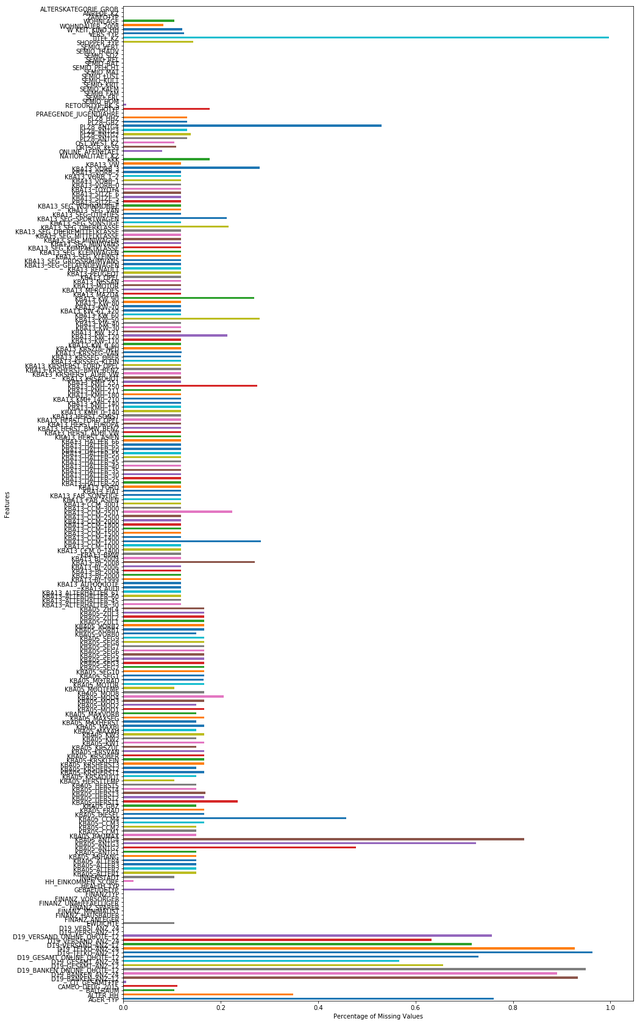

```python
missing_data = pd.Series(azdias.isnull().sum() / len(azdias))

missing_data.plot.barh(figsize=(15,30))
plt.xlabel('Percentage of Missing Values')
plt.ylabel('Features')

plt.show()
```

```python
missing_data_columns = missing_data[missing_data > 0.3].index.tolist()
```

```python
print(missing_data_columns)
```

```
['AGER_TYP', 'ALTER_HH', 'D19_BANKEN_ANZ_12', 'D19_BANKEN_ANZ_24', 'D19_BANKEN_ONLINE_QUOTE_12', 'D19_GESAMT_ANZ_12', 'D19_GESAMT_ANZ_24', 'D19_GESAMT_ONLINE_QUOTE_12', 'D19_TELKO_ANZ_12', 'D19_TELKO_ANZ_24', 'D19_VERSAND_ANZ_12', 'D19_VERSAND_ANZ_24', 'D19_VERSAND_ONLINE_QUOTE_12', 'KBA05_ANTG2', '…
```

```python
azdias.info()
```

```
<class 'pandas.core.frame.DataFrame'>
RangeIndex: 891221 entries, 0 to 891220
Columns: 237 entries, AGER_TYP to ALTERSKATEGORIE_GROB
dtypes: float64(235), object(2)
memory usage: 1.6+ GB
```

```python
azdias_subset = azdias.drop(missing_data_columns,axis=1)
```

```python
azdias_subset.head()
```

|  | BALLRAUM | CAMEO_DEUG_2015 | CJT_GESAMTTYP | D19_VERSI_ANZ_12 | D19_VERSI_ANZ_24 | EWDICHTE | FINANZ_ANLEGER | FINANZ_HAUSBAUER | FINANZ_MINIMALIST | FINANZ_SPARER | FINANZ_UNAUFFAELLIGER | FINANZ_VORSORGER | FINANZTYP | GEBAEUDETYP | HEALTH_TYP | HH_EINKOMMEN_SCORE | INNENSTADT | KBA05_ALTER1 | KBA05_ALTER2 | KBA05_ALTER3 | KBA05_ALTER4 | KBA05_ANHANG | KBA05_ANTG1 | KBA05_BAUMAX | KBA05_CCM1 | KBA05_CCM2 | KBA05_CCM3 | KBA05_DIESEL | KBA05_FRAU | … |
| --- | --- | --- | --- | --- | --- | --- | --- | --- | --- | --- | --- | --- | --- | --- | --- | --- | --- | --- | --- | --- | --- | --- | --- | --- | --- | --- | --- | --- | --- | --- |
| 0 | NaN | NaN | 2.0 | 0.0 | 0.0 | NaN | 5.0 | 3.0 | 3.0 | 4.0 | 5.0 | 3.0 | 4.0 | NaN | -1.0 | 2.0 | NaN | NaN | NaN | NaN | NaN | NaN | NaN | NaN | NaN | NaN | NaN | NaN | NaN | … |
| 1 | 6.0 | 8 | 5.0 | 0.0 | 0.0 | 3.0 | 5.0 | 5.0 | 1.0 | 5.0 | 4.0 | 2.0 | 1.0 | 8.0 | 3.0 | 6.0 | 8.0 | 3.0 | 4.0 | 1.0 | 4.0 | 0.0 | 0.0 | 5.0 | 1.0 | 5.0 | 1.0 | 2.0 | 4.0 | … |
| 2 | 2.0 | 4 | 3.0 | 0.0 | 0.0 | 4.0 | 2.0 | 5.0 | 1.0 | 4.0 | 3.0 | 1.0 | 1.0 | 1.0 | 3.0 | 4.0 | 4.0 | 2.0 | 3.0 | 3.0 | 3.0 | 0.0 | 1.0 | 0.0 | 5.0 | 2.0 | 3.0 | 0.0 | 3.0 | … |
| 3 | 4.0 | 2 | 2.0 | 0.0 | 0.0 | 2.0 | 2.0 | 2.0 | 4.0 | 2.0 | 1.0 | 5.0 | 6.0 | 1.0 | 2.0 | 1.0 | 6.0 | 2.0 | 5.0 | 3.0 | 0.0 | 1.0 | 4.0 | 1.0 | 2.0 | 3.0 | 5.0 | 3.0 | 4.0 | … |
| 4 | 2.0 | 6 | 5.0 | 1.0 | 3.0 | 5.0 | 1.0 | 2.0 | 4.0 | 3.0 | 3.0 | 4.0 | 5.0 | 1.0 | 3.0 | 5.0 | 1.0 | 0.0 | 4.0 | 4.0 | 3.0 | 0.0 | 1.0 | 0.0 | 4.0 | 1.0 | 4.0 | 1.0 | 5.0 | … |

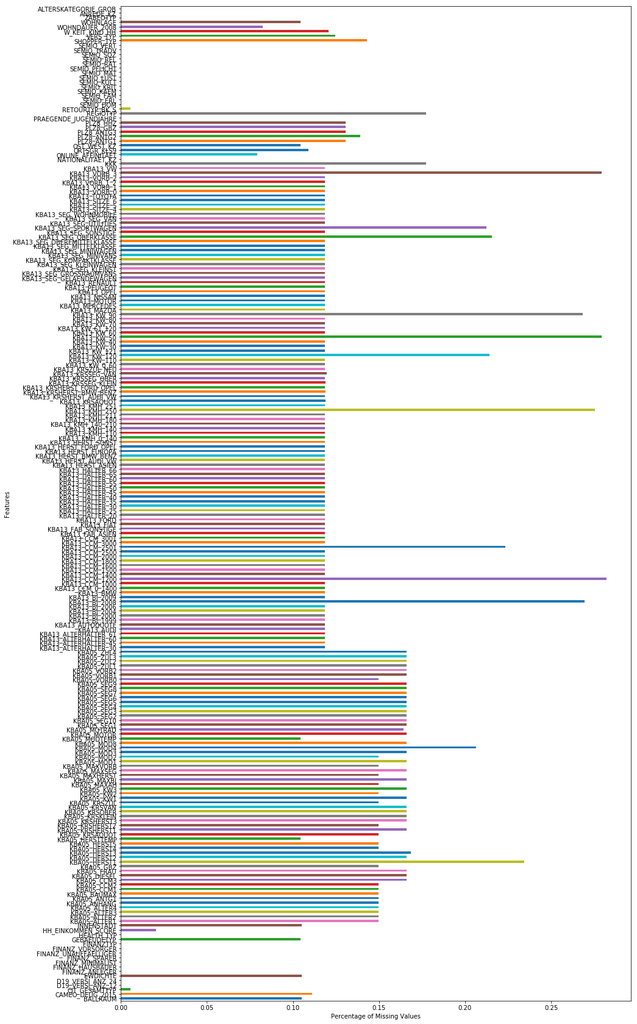

```python
missing_data = pd.Series(azdias_subset.isnull().sum() / len(azdias_subset))

missing_data.plot.barh(figsize=(15,30))
plt.xlabel('Percentage of Missing Values')
plt.ylabel('Features')

plt.show()
```

#### Discussion 1.1.2: Assess Missing Data in Each Column

Columns with more than 30% of missing values got dropped. The rest of the data will be used for further analysis.

#### Step 1.1.3: Assess Missing Data in Each Row

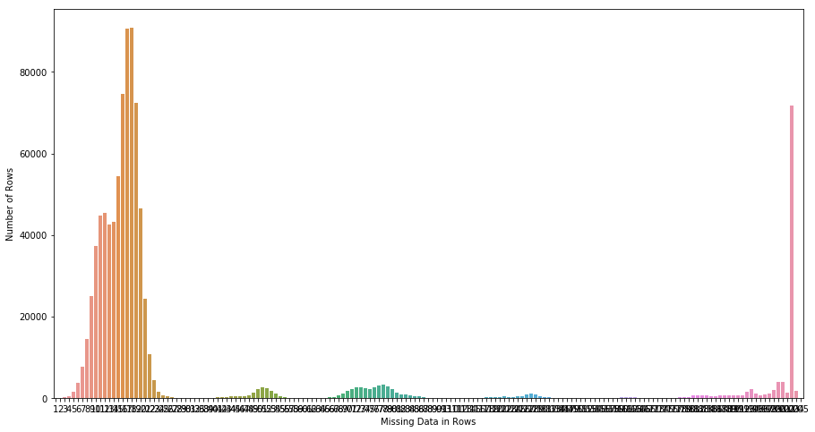

```python
missing_data_rows = azdias.isnull().sum(axis=1)

plt.figure(figsize=(15,8))
ax = sns.countplot(missing_data_rows)
ax.set_xlabel('Missing Data in Rows')
ax.set_ylabel('Number of Rows')
plt.show()
```

```python
# Write code to divide the data into two subsets based on the number of missing
# values in each row.

azdias['NaN_count'] = azdias.isnull().sum(axis=1)
missing_data_rows_below = azdias.query('NaN_count < 10')
missing_data_rows_below = missing_data_rows_below.drop('NaN_count',axis=1)
missing_data_rows_above = azdias.query('NaN_count >= 10')
missing_data_rows_above = missing_data_rows_above.drop('NaN_count',axis=1)
```

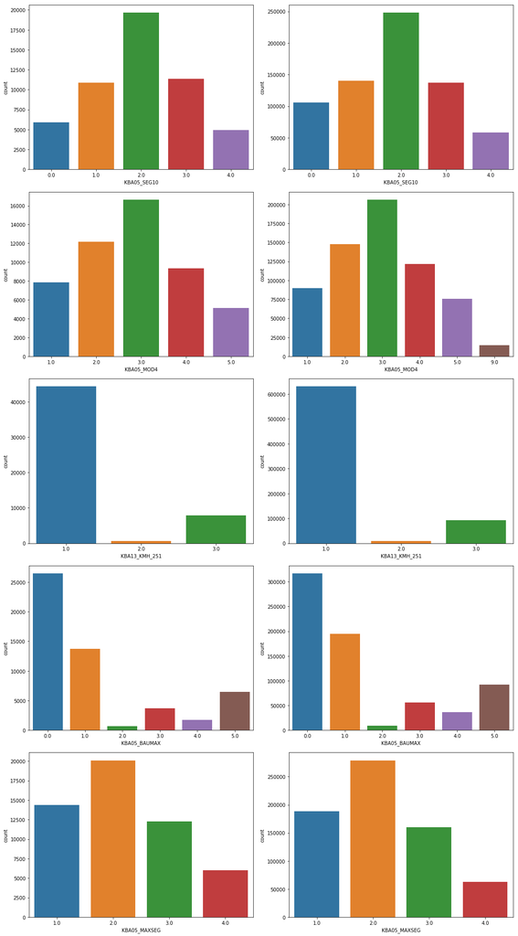

```python
# Compare the distribution of values for at least five columns where there are
# no or few missing values, between the two subsets.

no_missing_values = list(azdias.query('NaN_count == 0'))
random.seed(60)
random_column = random.sample(no_missing_values, 5)


def counterplot(random_column, below, above):
    plt.figure(figsize=(15,27))
    for i, column in enumerate(random_column):
        plt.subplot(5, 2, i*2 + 1)
        sns.countplot(x=column, data=below)
        plt.subplot(5, 2, i*2 + 2)
        sns.countplot(x=column, data=above)
        plt.tight_layout()

counterplot(random_column, missing_data_rows_below, missing_data_rows_above)
```

#### Discussion 1.1.3: Assess Missing Data in Each Row

The distributions for the random columns are almost smae between many and few missing values.

So I will use the dataset with few missing values for further analysis.

### Step 1.2: Select and Re-Encode Features

```python
feat_info.set_index('attribute', inplace=True)
```

```python
feat_info.head()
```

| attribute | type | meaning | missing_or_unknown |
| --- | --- | --- | --- |
| AGER_TYP | categorical | unknown | [-1] |
| ALTERSKATEGORIE_GROB | categorical | unknown | [-1, 0] |
| ALTER_HH | ordinal | unknown / no main age detectable | [0] |
| ANREDE_KZ | categorical | unknown | [-1, 0] |
| BALLRAUM | ordinal | unknown | [-1] |

```python
# How many features are there of each data type?

datatype = []

for each in missing_data_rows_below.columns:
    d = feat_info.loc[each].type
    datatype.append(d)

Counter(datatype)
```

```
Counter({'categorical': 20, 'ordinal': 216, 'mixed': 1})
```

#### Step 1.2.1: Re-Encode Categorical Features

```python
# Assess categorical variables: which are binary, which are multi-level, and
# which one needs to be re-encoded?

print('Binary Categorical variables:')
print(' ')

for each in missing_data_rows_below.columns:

    if feat_info.loc[each].type == 'categorical' and len(missing_data_rows_below[each].unique()) == 2:
        print(each)
#         print(each + ' ' + feat_info.loc[each].type)
#         print(missing_data_rows_below[each].unique())

print(' ')
print(' ')
print('Multi-level Categorical variables:')
print(' ')

multi_level = []

for each in missing_data_rows_below.columns:

    if feat_info.loc[each].type == 'categorical' and len(missing_data_rows_below[each].unique()) > 2:
        print(each)
        multi_level.append(each)
#         print(each + ' ' + feat_info.loc[each].type)
#         print(missing_data_rows_below[each].unique())

print(' ')
print(' ')
print('Mixed Categorical variables:')
print(' ')



for each in missing_data_rows_below.columns:

    if feat_info.loc[each].type == 'mixed':
        print(each)
#         print(each + ' ' + feat_info.loc[each].type)
#         print(missing_data_rows_below[each].unique())
```

```
Binary Categorical variables:

KBA05_SEG6
OST_WEST_KZ
ANREDE_KZ


Multi-level Categorical variables:

AGER_TYP
CAMEO_DEUG_2015
CJT_GESAMTTYP
FINANZTYP
GEBAEUDETYP
HEALTH_TYP
KBA05_MAXHERST
KBA05_MAXVORB
KBA05_MODTEMP
NATIONALITAET_KZ
REGIOTYP
RETOURTYP_BK_S
SHOPPER_TYP
TITEL_KZ
VERS_TYP
ZABEOTYP
ALTERSKATEGORIE_GROB


Mixed Categorical variables:

PRAEGENDE_JUGENDJAHRE
```

```python
# Re-encode categorical variable(s) to be kept in the analysis.

missing_data_rows_below.drop(multi_level, axis=1, inplace=True)

missing_data_rows_below = pd.get_dummies(data=missing_data_rows_below, columns=['OST_WEST_KZ','ANREDE_KZ','KBA05_SEG6'])

missing_data_rows_below.drop(['OST_WEST_KZ_W'], axis=1, inplace=True)

missing_data_rows_below.drop(['ANREDE_KZ_2.0'], axis=1, inplace=True)

missing_data_rows_below.drop(['KBA05_SEG6_1.0'], axis=1, inplace=True)

missing_data_rows_below.head()
```

|  | ALTER_HH | BALLRAUM | D19_BANKEN_ANZ_12 | D19_BANKEN_ANZ_24 | D19_BANKEN_ONLINE_QUOTE_12 | D19_GESAMT_ANZ_12 | D19_GESAMT_ANZ_24 | D19_GESAMT_ONLINE_QUOTE_12 | D19_TELKO_ANZ_12 | D19_TELKO_ANZ_24 | D19_VERSAND_ANZ_12 | D19_VERSAND_ANZ_24 | D19_VERSAND_ONLINE_QUOTE_12 | D19_VERSI_ANZ_12 | D19_VERSI_ANZ_24 | EWDICHTE | FINANZ_ANLEGER | FINANZ_HAUSBAUER | FINANZ_MINIMALIST | FINANZ_SPARER | FINANZ_UNAUFFAELLIGER | FINANZ_VORSORGER | HH_EINKOMMEN_SCORE | INNENSTADT | KBA05_ALTER1 | KBA05_ALTER2 | KBA05_ALTER3 | KBA05_ALTER4 | KBA05_ANHANG | … |
| --- | --- | --- | --- | --- | --- | --- | --- | --- | --- | --- | --- | --- | --- | --- | --- | --- | --- | --- | --- | --- | --- | --- | --- | --- | --- | --- | --- | --- | --- | --- |
| 4 | 20.0 | 2.0 | 3.0 | 5.0 | 10.0 | 6.0 | 6.0 | 10.0 | NaN | 1.0 | 6.0 | 6.0 | 10.0 | 1.0 | 3.0 | 5.0 | 1.0 | 2.0 | 4.0 | 3.0 | 3.0 | 4.0 | 5.0 | 1.0 | 0.0 | 4.0 | 4.0 | 3.0 | 0.0 | … |
| 41 | 20.0 | 2.0 | 1.0 | 1.0 | 10.0 | 6.0 | 6.0 | 9.0 | 1.0 | 1.0 | 5.0 | 6.0 | 10.0 | 0.0 | 0.0 | 4.0 | 5.0 | 2.0 | 2.0 | 5.0 | 5.0 | 3.0 | 2.0 | 4.0 | 3.0 | 3.0 | 3.0 | 2.0 | 1.0 | … |
| 66 | 21.0 | 2.0 | NaN | NaN | NaN | 2.0 | 4.0 | 5.0 | NaN | 2.0 | 2.0 | 2.0 | 5.0 | 0.0 | 0.0 | 5.0 | 5.0 | 5.0 | 1.0 | 5.0 | 5.0 | 2.0 | 6.0 | 4.0 | 3.0 | 3.0 | 3.0 | 3.0 | 1.0 | … |
| 79 | 21.0 | 6.0 | 2.0 | 4.0 | NaN | 5.0 | 6.0 | 8.0 | 1.0 | 4.0 | 4.0 | 6.0 | 9.0 | 2.0 | 3.0 | 5.0 | 5.0 | 5.0 | 1.0 | 5.0 | 5.0 | 2.0 | 5.0 | 6.0 | 0.0 | 1.0 | 5.0 | 0.0 | 0.0 | … |
| 84 | 13.0 | 1.0 | 1.0 | 1.0 | 10.0 | 1.0 | 1.0 | 10.0 | NaN | NaN | NaN | NaN | NaN | 0.0 | 0.0 | 6.0 | 1.0 | 4.0 | 3.0 | 1.0 | 1.0 | 5.0 | 5.0 | 3.0 | 3.0 | 3.0 | 3.0 | 4.0 | 0.0 | … |

#### Discussion 1.2.1: Re-Encode Categorical Features

For Multi-level Categorical variables, they will be dropped for further analysis.

The variable 'OST_WEST_KZ','ANREDE_KZ' and 'KBA05_SEG6' need be to re-encoded since it takes on non-numeric values.

#### Step 1.2.2: Engineer Mixed-Type Features

```python
# # Investigate "PRAEGENDE_JUGENDJAHRE" and engineer two new variables.

decade = {1:1, 2:1, 3:2, 4:2, 5:3, 6:3, 7:3, 8:4, 9:4, 10:5, 11:5, 12:5, 13:5, 14:6, 15:6}
missing_data_rows_below['PRAEGENDE_JUGENDJAHRE_DECADE'] = missing_data_rows_below['PRAEGENDE_JUGENDJAHRE'].map(decade)

movement = {1:0, 2:1, 3:0, 4:1, 5:0, 6:1, 7:1, 8:0, 9:1, 10:0, 11:1, 12:0, 13:1, 14:0, 15:1}
missing_data_rows_below['PRAEGENDE_JUGENDJAHRE_MOVEMENT'] = missing_data_rows_below['PRAEGENDE_JUGENDJAHRE'].map(movement)

missing_data_rows_below.drop('PRAEGENDE_JUGENDJAHRE', axis=1, inplace=True)

missing_data_rows_below.head()
```

|  | ALTER_HH | BALLRAUM | D19_BANKEN_ANZ_12 | D19_BANKEN_ANZ_24 | D19_BANKEN_ONLINE_QUOTE_12 | D19_GESAMT_ANZ_12 | D19_GESAMT_ANZ_24 | D19_GESAMT_ONLINE_QUOTE_12 | D19_TELKO_ANZ_12 | D19_TELKO_ANZ_24 | D19_VERSAND_ANZ_12 | D19_VERSAND_ANZ_24 | D19_VERSAND_ONLINE_QUOTE_12 | D19_VERSI_ANZ_12 | D19_VERSI_ANZ_24 | EWDICHTE | FINANZ_ANLEGER | FINANZ_HAUSBAUER | FINANZ_MINIMALIST | FINANZ_SPARER | FINANZ_UNAUFFAELLIGER | FINANZ_VORSORGER | HH_EINKOMMEN_SCORE | INNENSTADT | KBA05_ALTER1 | KBA05_ALTER2 | KBA05_ALTER3 | KBA05_ALTER4 | KBA05_ANHANG | … |
| --- | --- | --- | --- | --- | --- | --- | --- | --- | --- | --- | --- | --- | --- | --- | --- | --- | --- | --- | --- | --- | --- | --- | --- | --- | --- | --- | --- | --- | --- | --- |
| 4 | 20.0 | 2.0 | 3.0 | 5.0 | 10.0 | 6.0 | 6.0 | 10.0 | NaN | 1.0 | 6.0 | 6.0 | 10.0 | 1.0 | 3.0 | 5.0 | 1.0 | 2.0 | 4.0 | 3.0 | 3.0 | 4.0 | 5.0 | 1.0 | 0.0 | 4.0 | 4.0 | 3.0 | 0.0 | … |
| 41 | 20.0 | 2.0 | 1.0 | 1.0 | 10.0 | 6.0 | 6.0 | 9.0 | 1.0 | 1.0 | 5.0 | 6.0 | 10.0 | 0.0 | 0.0 | 4.0 | 5.0 | 2.0 | 2.0 | 5.0 | 5.0 | 3.0 | 2.0 | 4.0 | 3.0 | 3.0 | 3.0 | 2.0 | 1.0 | … |
| 66 | 21.0 | 2.0 | NaN | NaN | NaN | 2.0 | 4.0 | 5.0 | NaN | 2.0 | 2.0 | 2.0 | 5.0 | 0.0 | 0.0 | 5.0 | 5.0 | 5.0 | 1.0 | 5.0 | 5.0 | 2.0 | 6.0 | 4.0 | 3.0 | 3.0 | 3.0 | 3.0 | 1.0 | … |
| 79 | 21.0 | 6.0 | 2.0 | 4.0 | NaN | 5.0 | 6.0 | 8.0 | 1.0 | 4.0 | 4.0 | 6.0 | 9.0 | 2.0 | 3.0 | 5.0 | 5.0 | 5.0 | 1.0 | 5.0 | 5.0 | 2.0 | 5.0 | 6.0 | 0.0 | 1.0 | 5.0 | 0.0 | 0.0 | … |
| 84 | 13.0 | 1.0 | 1.0 | 1.0 | 10.0 | 1.0 | 1.0 | 10.0 | NaN | NaN | NaN | NaN | NaN | 0.0 | 0.0 | 6.0 | 1.0 | 4.0 | 3.0 | 1.0 | 1.0 | 5.0 | 5.0 | 3.0 | 3.0 | 3.0 | 3.0 | 4.0 | 0.0 | … |

### Step 1.3: Create a Cleaning Function

```python
def clean_data(df):
    """
    Perform the data preprocessing

    Input: dataframe
    Output: cleaned dataframe
    """

    df.drop(azdias_missing,axis=1,inplace=True)

    feat_info = pd.read_csv('DIAS Attributes - Values 2017_final.csv',delimiter=',')

    feat_info.set_index('attribute', inplace=True)

    feat_info.drop(feat_info_missing, inplace=True)

    feat_info.reset_index(inplace=True)

    feat_info['missing_or_unknown'] = feat_info['missing_or_unknown'].apply(lambda x: x[1:-1].split(','))

    for attribute, missing_or_unknown in zip(feat_info['attribute'], feat_info['missing_or_unknown']):
        if missing_or_unknown[0] == '':
            df[attribute] = df[attribute].replace('',np.nan)

        elif len(missing_or_unknown) > 1:
            for each in missing_or_unknown:
                each = int(each)
                df.loc[df[attribute] == each, [attribute]] = np.nan
        else:
            for each in missing_or_unknown:
                each = int(each)
                df.loc[df[attribute] == each, [attribute]] = np.nan


    missing_data = pd.Series(df.isnull().sum() / len(df))

    missing_data_columns = missing_data[missing_data > 0.3].index.tolist()

    df_clean = df.drop(missing_data_columns,axis=1)


    df_clean['NaN_count'] = df_clean.isnull().sum(axis=1)
    missing_data_rows_below = df_clean.query('NaN_count < 10')
    missing_data_rows_below = missing_data_rows_below.drop('NaN_count',axis=1)

    multi_level = []

    feat_info.set_index('attribute', inplace=True)

    for each in missing_data_rows_below.columns:
        if each == 'RESPONSE':
            continue
        elif feat_info.loc[each].type == 'categorical' and len(missing_data_rows_below[each].unique()) > 2:
            multi_level.append(each)

    missing_data_rows_below.drop(multi_level, axis=1, inplace=True)

    missing_data_rows_below = pd.get_dummies(data=missing_data_rows_below, columns=['OST_WEST_KZ','ANREDE_KZ'])

    missing_data_rows_below.drop(['OST_WEST_KZ_W'], axis=1, inplace=True)

    missing_data_rows_below.drop(['ANREDE_KZ_2.0'], axis=1, inplace=True)

    decade = {1:1, 2:1, 3:2, 4:2, 5:3, 6:3, 7:3, 8:4, 9:4, 10:5, 11:5, 12:5, 13:5, 14:6, 15:6}
    missing_data_rows_below['PRAEGENDE_JUGENDJAHRE_DECADE'] = missing_data_rows_below['PRAEGENDE_JUGENDJAHRE'].map(decade)

    movement = {1:0, 2:1, 3:0, 4:1, 5:0, 6:1, 7:1, 8:0, 9:1, 10:0, 11:1, 12:0, 13:1, 14:0, 15:1}
    missing_data_rows_below['PRAEGENDE_JUGENDJAHRE_MOVEMENT'] = missing_data_rows_below['PRAEGENDE_JUGENDJAHRE'].map(movement)

    missing_data_rows_below.drop('PRAEGENDE_JUGENDJAHRE', axis=1, inplace=True)


    return missing_data_rows_below
```

## Step 2: Feature Transformation

### Step 2.1: Apply Feature Scaling

```python
# find out if the dataset has any missing value

missing_data_rows_below.isnull().values.any()
```

```
True
```

```python
for each in missing_data_rows_below.columns:
    missing_data_rows_below[each] = missing_data_rows_below[each].fillna(missing_data_rows_below[each].mode()[0])

missing_data_rows_below.isnull().values.any()
```

```
False
```

```python
# Apply feature scaling to the general population demographics data.
scaler = StandardScaler()
missing_data_rows_below[missing_data_rows_below.columns] = scaler.fit_transform(missing_data_rows_below[missing_data_rows_below.columns])

missing_data_rows_below.head()
```

|  | ALTER_HH | BALLRAUM | D19_BANKEN_ANZ_12 | D19_BANKEN_ANZ_24 | D19_BANKEN_ONLINE_QUOTE_12 | D19_GESAMT_ANZ_12 | D19_GESAMT_ANZ_24 | D19_GESAMT_ONLINE_QUOTE_12 | D19_TELKO_ANZ_12 | D19_TELKO_ANZ_24 | D19_VERSAND_ANZ_12 | D19_VERSAND_ANZ_24 | D19_VERSAND_ONLINE_QUOTE_12 | D19_VERSI_ANZ_12 | D19_VERSI_ANZ_24 | EWDICHTE | FINANZ_ANLEGER | FINANZ_HAUSBAUER | FINANZ_MINIMALIST | FINANZ_SPARER | FINANZ_UNAUFFAELLIGER | FINANZ_VORSORGER | HH_EINKOMMEN_SCORE | INNENSTADT | KBA05_ALTER1 | KBA05_ALTER2 | KBA05_ALTER3 | KBA05_ALTER4 | KBA05_ANHANG | … |
| --- | --- | --- | --- | --- | --- | --- | --- | --- | --- | --- | --- | --- | --- | --- | --- | --- | --- | --- | --- | --- | --- | --- | --- | --- | --- | --- | --- | --- | --- | --- |
| 4 | 0.903511 | -0.841901 | 1.574949 | 2.600188 | 0.1089 | 2.195870 | 1.501260 | 0.459400 | -0.254456 | -0.343683 | 3.025608 | 2.007957 | 0.359745 | 0.902543 | 2.470252 | 0.492981 | -1.204232 | -0.725906 | 0.673425 | 0.137914 | 0.275581 | 0.382625 | 0.471700 | -1.713551 | -1.633951 | 0.949621 | 0.905301 | 0.127492 | -1.026608 | … |
| 41 | 0.903511 | -0.841901 | -0.507920 | -0.643585 | 0.1089 | 2.195870 | 1.501260 | -0.067779 | -0.254456 | -0.343683 | 2.202730 | 2.007957 | 0.359745 | -0.471027 | -0.600355 | -0.127247 | 1.519827 | -0.725906 | -0.771324 | 1.450122 | 1.700759 | -0.340568 | -1.410427 | -0.178919 | 0.974686 | -0.017016 | -0.052545 | -0.720628 | 0.074801 | … |
| 66 | 1.186975 | -0.841901 | -0.507920 | -0.643585 | 0.1089 | -0.766498 | 0.043090 | -2.176498 | -0.254456 | 1.545214 | -0.265904 | -0.773593 | -2.715814 | -0.471027 | -0.600355 | 0.492981 | 1.519827 | 1.394437 | -1.493698 | 1.450122 | 1.700759 | -1.063762 | 1.099076 | -0.178919 | 0.974686 | -0.017016 | -0.052545 | 0.127492 | 0.074801 | … |
| 79 | 1.186975 | 0.983812 | 0.533515 | 1.789245 | 0.1089 | 1.455278 | 1.501260 | -0.594959 | -0.254456 | 5.323007 | 1.379852 | 2.007957 | -0.255367 | 2.276113 | 2.470252 | 0.492981 | 1.519827 | 1.394437 | -1.493698 | 1.450122 | 1.700759 | -1.063762 | 0.471700 | 0.844169 | -1.633951 | -1.950292 | 1.863147 | -2.416866 | -1.026608 | … |
| 84 | -1.080740 | -1.298329 | -0.507920 | -0.643585 | 0.1089 | -1.507090 | -2.144163 | 0.459400 | -0.254456 | -0.343683 | -0.265904 | -0.773593 | 0.359745 | -0.471027 | -0.600355 | 1.113209 | -1.204232 | 0.687656 | -0.048949 | -1.174293 | -1.149597 | 1.105819 | 0.471700 | -0.690463 | 0.974686 | -0.017016 | -0.052545 | 0.975611 | -1.026608 | … |

### Discussion 2.1: Apply Feature Scaling

The null values have been imputed with mode values from the dataset. The whole dataset has been normalized using StandardScaler module from scikit learn library.

### Step 2.2: Perform Dimensionality Reduction

```python
# Apply PCA to the data.

pca = PCA()
missing_data_rows_below_pca = pca.fit_transform(missing_data_rows_below)
```

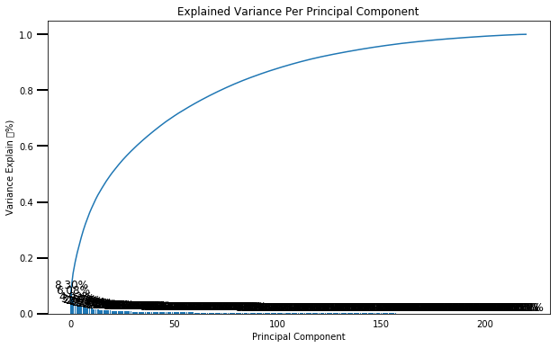

```python
# Investigate the variance accounted for by each principal component.

def screen_plot(pca):
    '''
    Creates a scree plot associated with the principal components

    INPUT: pca - the result of instantian of PCA in scikit learn

    OUTPUT:
            None
    '''
    num_components = len(pca.explained_variance_ratio_)
    ind = np.arange(num_components)
    vals = pca.explained_variance_ratio_

    plt.figure(figsize=(10,6))
    ax = plt.subplot(111)
    cumvals = np.cumsum(vals)
    ax.bar(ind, vals)
    ax.plot(ind, cumvals)
    for i in range(num_components):
        ax.annotate(r"%s%%" % ((str(vals[i]*100)[:4])), (ind[i]+0.2, vals[i]), va="bottom", ha="center", fontsize=12)

    ax.xaxis.set_tick_params(width=0)
    ax.yaxis.set_tick_params(width=2, length=12)

    ax.set_xlabel("Principal Component")
    ax.set_ylabel("Variance Explain （%)")
    plt.title('Explained Variance Per Principal Component')

screen_plot(pca)
```

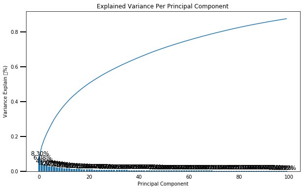

```python
# Re-apply PCA to the data while selecting for number of components to retain.

pca = PCA(n_components=100)
missing_data_rows_below_pca = pca.fit_transform(missing_data_rows_below)
screen_plot(pca)
```

```python
# Calculate the total variance ratio
pca.explained_variance_ratio_.sum()
```

```
0.87508048054517262
```

### Discussion 2.2: Perform Dimensionality Reduction

Based on the total variance ratio, 87% of total variance can be explained by 100 components. So I will use 100 components for Dimensionality Reduction Analysis.

### Step 2.3: Interpret Principal Components

```python
# Map weights for the first principal component to corresponding feature names
# and then print the linked values, sorted by weight.
# HINT: Try defining a function here or in a new cell that you can reuse in the
# other cells.

def pca_results(data, pca, comp):

    feature = data.columns.tolist()
    component = pca.components_[comp].tolist()
    feature_weight = pd.DataFrame(list(zip(feature, component)))
    feature_weight.set_axis(['Feature', 'Weight'], axis=1, inplace=True)
    feature_weight = feature_weight.sort_values(by=['Weight'] , ascending=False)

    return feature_weight

first_component = pca_results(missing_data_rows_below, pca, 1)
print(first_component.head())
print(first_component.tail())
```

```
                  Feature    Weight
86   KBA13_ALTERHALTER_60  0.201643
89        KBA13_AUTOQUOTE  0.199883
193            PLZ8_ANTG1  0.197221
120       KBA13_HALTER_55  0.188520
119       KBA13_HALTER_50  0.177713
         Feature    Weight
196   PLZ8_ANTG4 -0.145418
194   PLZ8_ANTG2 -0.161347
192  ORTSGR_KLS9 -0.205369
195   PLZ8_ANTG3 -0.205777
15      EWDICHTE -0.215090
```

```python
# Map weights for the second principal component to corresponding feature names
# and then print the linked values, sorted by weight.

second_component = pca_results(missing_data_rows_below, pca, 2)
print(second_component.head())
print(second_component.tail())
```

```
               Feature    Weight
21    FINANZ_VORSORGER  0.209785
200          SEMIO_ERL  0.199003
205         SEMIO_LUST  0.165898
18   FINANZ_MINIMALIST  0.116802
213     W_KEIT_KIND_HH  0.107815
                          Feature    Weight
20          FINANZ_UNAUFFAELLIGER -0.215189
207                 SEMIO_PFLICHT -0.222751
209                     SEMIO_REL -0.235480
219  PRAEGENDE_JUGENDJAHRE_DECADE -0.242796
19                  FINANZ_SPARER -0.249608
```

```python
# Map weights for the third principal component to corresponding feature names
# and then print the linked values, sorted by weight.

third_component = pca_results(missing_data_rows_below, pca, 3)
print(third_component.head())
print(third_component.tail())
```

```
                  Feature    Weight
154       KBA13_KW_61_120  0.185861
216         OST_WEST_KZ_O  0.176519
181         KBA13_SITZE_5  0.170676
84   KBA13_ALTERHALTER_30  0.153547
114       KBA13_HALTER_25  0.149383
              Feature    Weight
132     KBA13_KMH_140 -0.151519
97   KBA13_CCM_0_1400 -0.154944
180     KBA13_SITZE_4 -0.159694
91      KBA13_BJ_2000 -0.161008
146     KBA13_KW_0_60 -0.198122
```

## Step 3: Clustering

### Step 3.1: Apply Clustering to General Population

```python
# Over a number of different cluster counts...
# run k-means clustering on the data and...
# compute the average within-cluster distances.


def get_kmeans_score(data, center):

    kmeans = KMeans(n_clusters=center)

    model = kmeans.fit(data)

    score = np.abs(model.score(data))

    return score

scores = []
centers = list(range(1,25,2))

for center in centers:
    scores.append(get_kmeans_score(missing_data_rows_below_pca, center))
```

```
Text(0.5,1,'SSE vs. K')
```

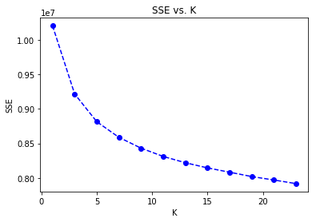

```python
# Investigate the change in within-cluster distance across number of clusters.
# HINT: Use matplotlib's plot function to visualize this relationship.

plt.plot(centers, scores, linestyle='--', marker='o', color='b')
plt.xlabel('K');
plt.ylabel('SSE');
plt.title('SSE vs. K')
```

```python
# Re-fit the k-means model with the selected number of clusters and obtain
# cluster predictions for the general population demographics data.

model = KMeans(n_clusters=15).fit(missing_data_rows_below_pca)

general_prediction = model.predict(missing_data_rows_below_pca)
```

### Discussion 3.1: Apply Clustering to General Population

Based on the plot, I picked '15' for the number of clusters using elbow method. The rate of change at 15 tends to decrease.

### Step 3.2: Apply All Steps to the Customer Data

```python
# Apply preprocessing, feature transformation, and clustering from the general
# demographics onto the customer data, obtaining cluster predictions for the
# customer demographics data.

customer_new = clean_data(customer)

for each in customer_new.columns:
    customer_new[each] = customer_new[each].fillna(customer_new[each].mode()[0])

customer_new.isnull().values.any()
```

```
False
```

```python
customer_new.head()
```

|  | BALLRAUM | D19_VERSI_ANZ_12 | D19_VERSI_ANZ_24 | EWDICHTE | FINANZ_ANLEGER | FINANZ_HAUSBAUER | FINANZ_MINIMALIST | FINANZ_SPARER | FINANZ_UNAUFFAELLIGER | FINANZ_VORSORGER | HH_EINKOMMEN_SCORE | INNENSTADT | KBA05_ALTER1 | KBA05_ALTER2 | KBA05_ALTER3 | KBA05_ALTER4 | KBA05_ANHANG | KBA05_ANTG1 | KBA05_BAUMAX | KBA05_CCM1 | KBA05_CCM2 | KBA05_CCM3 | KBA05_DIESEL | KBA05_FRAU | KBA05_GBZ | KBA05_HERST2 | KBA05_HERST4 | KBA05_HERST5 | KBA05_HERSTTEMP | … |
| --- | --- | --- | --- | --- | --- | --- | --- | --- | --- | --- | --- | --- | --- | --- | --- | --- | --- | --- | --- | --- | --- | --- | --- | --- | --- | --- | --- | --- | --- | --- |
| 0 | 3.0 | 0.0 | 0.0 | 2.0 | 1.0 | 2.0 | 5.0 | 1.0 | 2.0 | 5.0 | 1.0 | 4.0 | 2.0 | 2.0 | 4.0 | 4.0 | 1.0 | 2.0 | 0.0 | 3.0 | 3.0 | 3.0 | 1.0 | 4.0 | 4.0 | 3.0 | 2.0 | 2.0 | 2.0 | … |
| 2 | 7.0 | 0.0 | 0.0 | 4.0 | 1.0 | 4.0 | 5.0 | 1.0 | 4.0 | 5.0 | 1.0 | 1.0 | 2.0 | 4.0 | 2.0 | 3.0 | 3.0 | 2.0 | 0.0 | 2.0 | 2.0 | 5.0 | 4.0 | 4.0 | 3.0 | 4.0 | 2.0 | 3.0 | 2.0 | … |
| 3 | 7.0 | 0.0 | 0.0 | 1.0 | 2.0 | 2.0 | 5.0 | 1.0 | 1.0 | 5.0 | 4.0 | 7.0 | 2.0 | 3.0 | 3.0 | 3.0 | 3.0 | 3.0 | 1.0 | 3.0 | 4.0 | 2.0 | 3.0 | 2.0 | 4.0 | 1.0 | 5.0 | 3.0 | 3.0 | … |
| 4 | 3.0 | 0.0 | 0.0 | 4.0 | 4.0 | 2.0 | 3.0 | 1.0 | 5.0 | 4.0 | 6.0 | 4.0 | 2.0 | 4.0 | 4.0 | 1.0 | 0.0 | 0.0 | 0.0 | 2.0 | 5.0 | 2.0 | 2.0 | 3.0 | 3.0 | 4.0 | 2.0 | 3.0 | 1.0 | … |
| 5 | 7.0 | 0.0 | 0.0 | 5.0 | 1.0 | 3.0 | 5.0 | 1.0 | 2.0 | 5.0 | 1.0 | 8.0 | 0.0 | 2.0 | 3.0 | 5.0 | 0.0 | 2.0 | 0.0 | 3.0 | 2.0 | 3.0 | 1.0 | 5.0 | 3.0 | 4.0 | 3.0 | 3.0 | 2.0 | … |

```python
customer_new[customer_new.columns] = scaler.fit_transform(customer_new[customer_new.columns])

customer_new_pca = pca.fit_transform(customer_new)

customer_prediction = model.predict(customer_new_pca)
```